# Sales Prediction Using Machine Learning: A Project Overview

## Introduction

In the world of business, predicting sales accurately can make a huge difference. Imagine knowing how much of a product you will sell based on how much you spend on advertising. This project aims to do exactly that—using machine learning to predict sales based on advertising expenditure across different media like TV, radio, and newspapers.

## 1). Data Preprocessing

### Loading the Data

We started with a dataset containing information on advertising expenses and sales figures. The data had 200 entries, each representing a different advertising campaign.

### Exploring the Data

Our first step was to understand the dataset. We looked at the first few rows to get a sense of the data and checked for any missing values. Fortunately, our dataset was complete with no missing entries.

### Feature Selection

We selected three main features—TV, Radio, and Newspaper—since these represent our advertising expenditures. Our target variable, the one we want to predict, is Sales.

## 2). Data Visualization

### Understanding Relationships

We used visual tools to understand how our features (TV, Radio, Newspaper) relate to our target variable (Sales). For this, we plotted graphs showing the relationships between each type of advertising and sales. These visualizations helped us see trends and patterns that are not immediately obvious from raw data.

### Correlation Analysis

Next, we calculated and visualized the correlations between different features and sales. This helped us identify which types of advertising had the strongest impact on sales.

## 3). Splitting the Data

### Train-Test Split

To evaluate our model's performance accurately, we split our data into two sets: a training set to build the model and a test set to evaluate it. This way, we can see how well our model performs on data it hasn't seen before.

## 4). Model Building

### Linear Regression

We chose Linear Regression, a straightforward yet powerful machine learning technique, to predict sales. This model works by finding the best-fit line through our data points, which helps us understand how different factors contribute to sales.

### Training the Model

We trained our model using the training data. The model learned the relationship between advertising expenditures and sales.

### Evaluating the Model

After training, we tested our model using the test data. The key metrics we looked at were Mean Squared Error (MSE) and R² Score. MSE tells us how close our predictions are to the actual sales values, and R² Score indicates how well our model explains the variability of the data. Our model achieved an MSE of 2.91 and an R² Score of 0.91, indicating strong predictive power.

### Cross-Validation

To further validate our model, we used cross-validation, a technique that ensures our model's performance is consistent across different subsets of the data. Our model showed an average cross-validation score of 0.90, reinforcing its reliability.

## 5). Deployment

### Saving the Model

Once we were satisfied with our model's performance, we saved it for future use. This allows us to make sales predictions quickly and easily without having to retrain the model every time.

### Making Predictions

We tested our saved model with new data. For example, when we input advertising spends of $150 on TV, $20 on Radio, and $30 on Newspapers, the model predicted sales of approximately 15 units.

```python
import pandas as pd
import numpy as np
import seaborn as sns
import matplotlib.pyplot as plt
from sklearn.model_selection import train_test_split
from sklearn.linear_model import LinearRegression
from sklearn.metrics import mean_squared_error, r2_score
from sklearn.model_selection import cross_val_score
import joblib
```

# 1). Data Preprocessing

### Load Data

```python
dataset = pd.read_csv(r"C:\Users\Arsalan Khatri\Desktop\intership work\Projects\SALES PREDICTION USING PYTHON\dataset\advertising.csv")
```

### Explore the Data

```python
dataset.head()
```

|  | TV | Radio | Newspaper | Sales |
| --- | --- | --- | --- | --- |
| 0 | 230.1 | 37.8 | 69.2 | 22.1 |
| 1 | 44.5 | 39.3 | 45.1 | 10.4 |
| 2 | 17.2 | 45.9 | 69.3 | 12.0 |
| 3 | 151.5 | 41.3 | 58.5 | 16.5 |
| 4 | 180.8 | 10.8 | 58.4 | 17.9 |

```python
dataset.tail()
```

|  | TV | Radio | Newspaper | Sales |
| --- | --- | --- | --- | --- |
| 195 | 38.2 | 3.7 | 13.8 | 7.6 |
| 196 | 94.2 | 4.9 | 8.1 | 14.0 |
| 197 | 177.0 | 9.3 | 6.4 | 14.8 |
| 198 | 283.6 | 42.0 | 66.2 | 25.5 |
| 199 | 232.1 | 8.6 | 8.7 | 18.4 |

```python
print(f"Total Rows {dataset.shape[0]}")
print(f"Total Columns {dataset.shape[1]}")
```

```
Total Rows 200
Total Columns 4
```

```python
dataset.columns
```

```
Index(['TV', 'Radio', 'Newspaper', 'Sales'], dtype='object')
```

```python
dataset.info()
```

```
<class 'pandas.core.frame.DataFrame'>
RangeIndex: 200 entries, 0 to 199
Data columns (total 4 columns):
 #   Column     Non-Null Count  Dtype
---  ------     --------------  -----
 0   TV         200 non-null    float64
 1   Radio      200 non-null    float64
 2   Newspaper  200 non-null    float64
 3   Sales      200 non-null    float64
dtypes: float64(4)
memory usage: 6.4 KB
```

```python
dataset.describe()
```

|  | TV | Radio | Newspaper | Sales |
| --- | --- | --- | --- | --- |
| count | 200.000000 | 200.000000 | 200.000000 | 200.000000 |
| mean | 147.042500 | 23.264000 | 30.554000 | 15.130500 |
| std | 85.854236 | 14.846809 | 21.778621 | 5.283892 |
| min | 0.700000 | 0.000000 | 0.300000 | 1.600000 |
| 25% | 74.375000 | 9.975000 | 12.750000 | 11.000000 |
| 50% | 149.750000 | 22.900000 | 25.750000 | 16.000000 |
| 75% | 218.825000 | 36.525000 | 45.100000 | 19.050000 |
| max | 296.400000 | 49.600000 | 114.000000 | 27.000000 |

### Check for Missing Values:

```python
dataset.isna().sum()
```

```
TV           0
Radio        0
Newspaper    0
Sales        0
dtype: int64
```

### Feature Selection:

```python
features = dataset[['TV', 'Radio', 'Newspaper']]
target = dataset['Sales']
```

# 2). Data Visualization

### Visualize Relationships

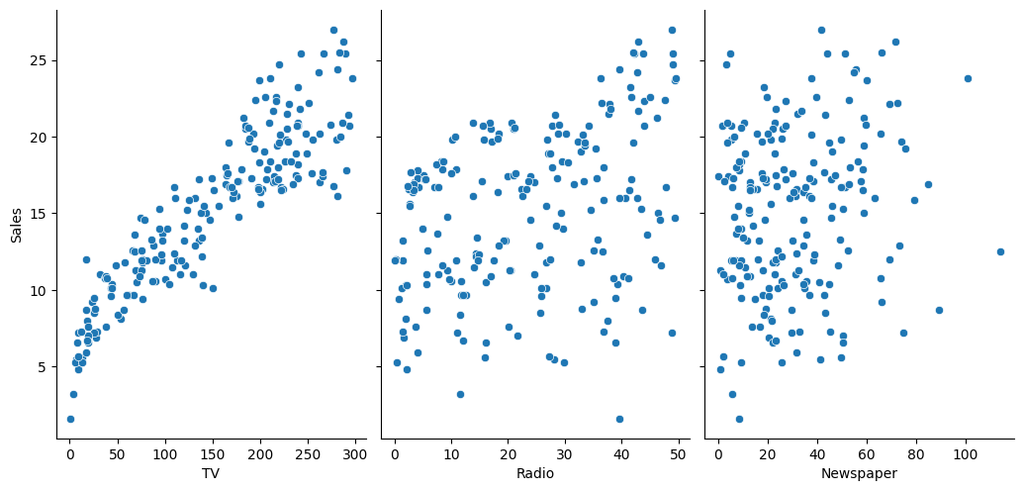

```python
sns.pairplot(dataset, x_vars=['TV', 'Radio', 'Newspaper'], y_vars='Sales', height=5, aspect=0.7)
plt.show()
```

### Correlation Matrix

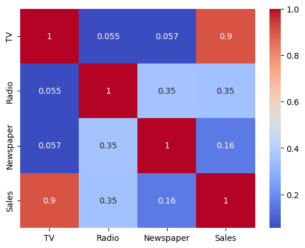

```python
corr = dataset.corr()
sns.heatmap(corr, annot=True, cmap='coolwarm')
plt.show()
```

# 3). Split the Data

### Train-Test Split

```python
X_train, X_test, y_train, y_test = train_test_split(features, target, test_size=0.2, random_state=42)
```

# 4). Model Building

### Linear Regression

```python
model = LinearRegression()
model.fit(X_train, y_train)
```

```
LinearRegression()
```

### Model Evaluation

```python
y_pred = model.predict(X_test)
mse = mean_squared_error(y_test, y_pred)
r2 = r2_score(y_test, y_pred)

print(f'Mean Squared Error: {mse}')
print(f'R^2 Score: {r2}')
```

```
Mean Squared Error: 2.907756910271091
R^2 Score: 0.9059011844150826
```

### Cross-Validation

```python
cv_scores = cross_val_score(model, features, target, cv=5)
print(f'Cross-Validation Scores: {cv_scores}')
print(f'Average CV Score: {cv_scores.mean()}')
```

```
Cross-Validation Scores: [0.87556263 0.93177791 0.92150403 0.84554586 0.90247132]
Average CV Score: 0.8953723525274103
```

# 5). Deployment

### Save the Model

```python
joblib.dump(model, 'sales_prediction_model.pkl')
```

```
['sales_prediction_model.pkl']
```

### Load and Predict

```python
loaded_model = joblib.load('sales_prediction_model.pkl')
# new_data = [[150, 20, 30]] # Example new data
new_data = pd.DataFrame([[150, 20, 30]], columns=['TV', 'Radio', 'Newspaper'])
# Make prediction
prediction = loaded_model.predict(new_data)
print(f'Sales Prediction: {prediction[0]}')
```

```
Sales Prediction: 15.039523680317233
```